# Snapper - Status Report

## Status Report

- Model Complete
  - 712
  - 800 Boats
  - Length Structured
- Parametrized…
  - …but length structure very optimistic
  - more work on this needed

## Slices

- Slice 0:
  - Full human side
  - One species model
- Slice 1:
  - Full human side
  - 5 species model
  - Biomass Only
- Slice 2:
  - Full human side
  - 5 species model
  - Length Structure

## Slice 0

| class | fishing_gear | GT | landings |
| --- | --- | --- | --- |
| Big | Longline | 42.583333 | 1533.0 |
| Medium | Dropline | 17.210526 | 981.0 |
| Medium | Longline | 26.838235 | 2737.5 |
| Small | Dropline | 8.445669 | 8044.5 |
| Small | Longline | 11.083333 | 199.5 |

## Parametrize a fleet

- Fleet Census:
  - Number and position
- Survey data:
  - Variable Cost
  - Max Trip Length
  - Exploration Probability
- CODRS:
  - Avg Trip Distance (for mileage)
  - Hold Size
- Calibrate to:
  - Landing table

## Slice 1

- Add 4(+1) species
  - Biomass Only
  - Calibrate to landings per species per population
- Advantages:
  - cMSY
  - runs fast (easy to parametrize)
  - easy to understand
- Disadvantages:
  - No real SPR numbers
  - Cannot replicate TNC

## Calibrates Easily

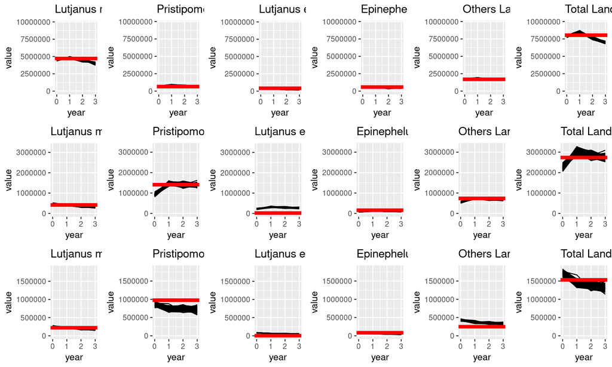

## Easy to make policies with (1)

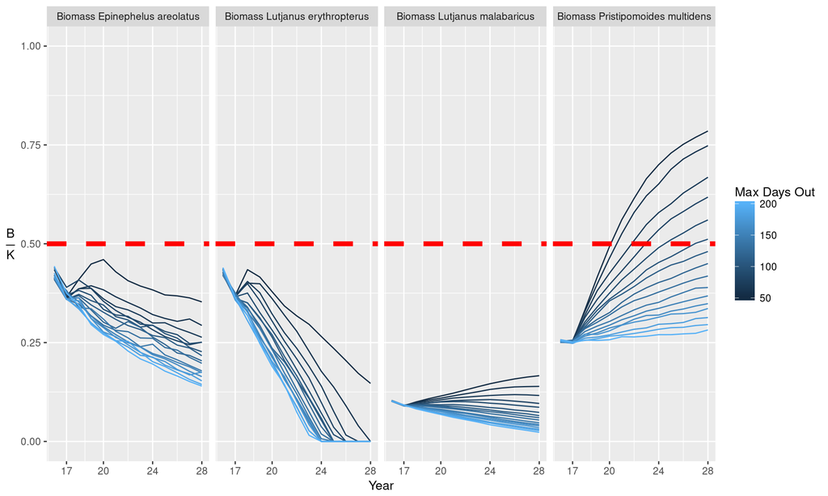

## Easy to make policies with (2)

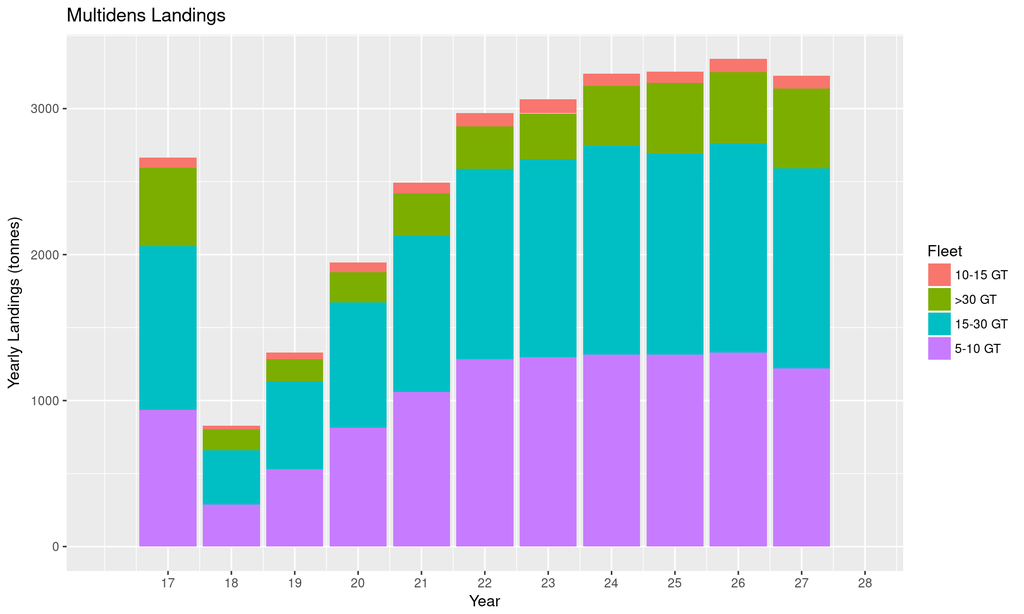

## Easy to make policies with (3)

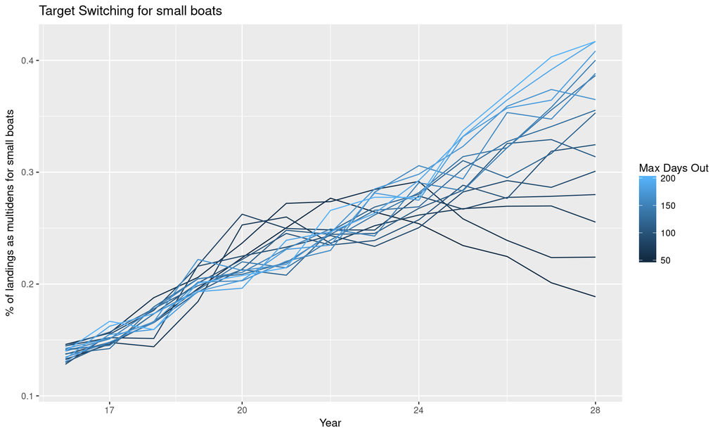

## Easy to make policies with (4)

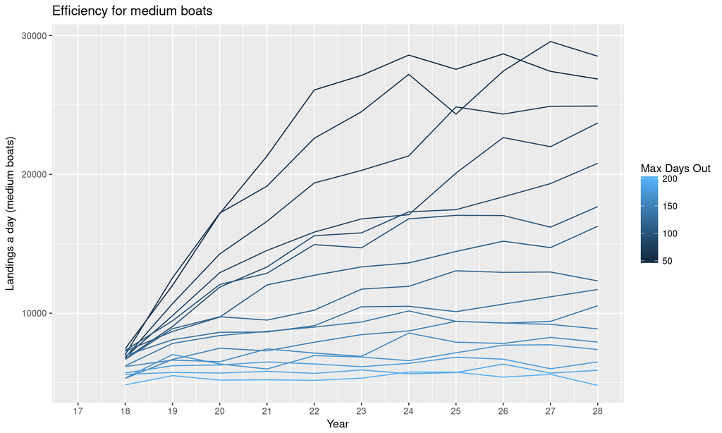

## Easy to make policies with (5)

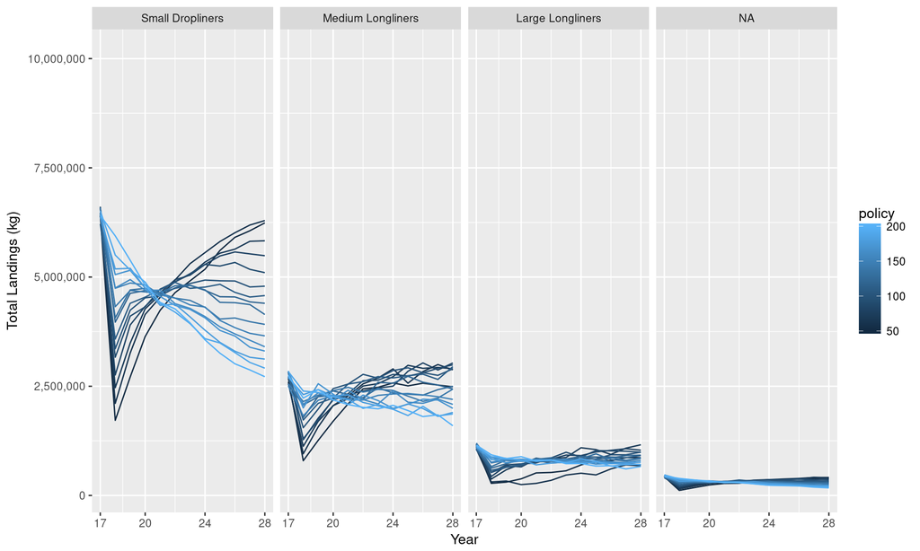

## Easy to make policies with (6)

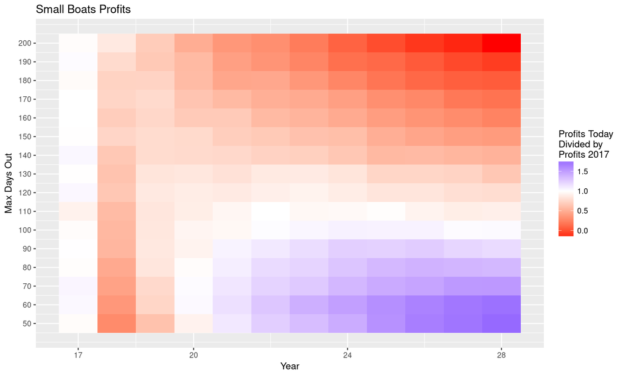

## Slice 2

- Length-based biomass
- Cons:
  - MANY parameters
  - no simple published technique to follow
  - slow to simulate

## Can simulate SPR sampling

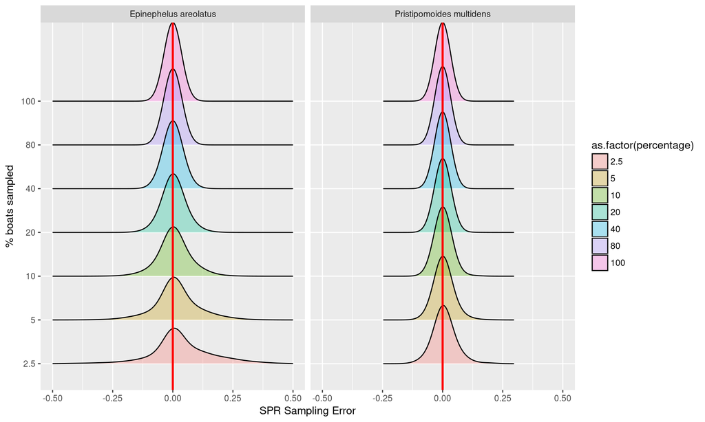

## Compute Failure Rates

| % Sampled | Epinephelus areolatus | Pristipomoides multidens |
| --- | --- | --- |
| 2.5 | 0.3403 | 0.0337 |
| 5.0 | 0.2279 | 0.0166 |
| 10.0 | 0.1229 | 0.0070 |
| 20.0 | 0.0326 | 0.0013 |
| 40.0 | 0.0018 | 0.0000 |
| 80.0 | 0.0000 | 0.0000 |
| 100.0 | 0.0000 | 0.0000 |

## Other things to do

- Price Premium
- SPR Driven Closures

## What’s missing?

- Population grows too fast
  - Can calibrate the model to land the right numbers
  - But biomass grows dramatically under those circumstances
- Possible Problems:
  - Recruitment too optimistic
  - Initial population wrong
  - Selectivity off
  - Bug